# Tarea 3 - Redes

En el presente trabajo se utilizó la base de datos de Transparencia Perú, que incluye los nombres de todos los congresistas de la República correspondiente al año congresal 2023-2024, así como los lugares visitados según los informes de la semana de representación presentados en la página web del Congreso de la República del Perú durante dicho periodo. Es importante señalar que la base de datos presenta vacíos, por lo que se trabajó con un total de 94 congresistas de los 130.

```python
import pandas as pd

# Leer el archivo CSV
data = pd.read_csv("mi_data_limpia.csv")

# Mostrar las primeras filas de los datos
print(data.head())
```

```
                          Congresistas  \
0        Acuña Peralta María Grimaneza
1         Acuña Peralta Segundo Héctor
2  Aguinaga Recuenco Alejandro Aurelio
3     Agüero Gutierrez María Antonieta
4           Alcarraz Aguero Yorel Kira

                                   lugares_visitados
0  LIMA, CHICLAYO, LAMBAYEQUE, CHICLAYO, LAMBAYEQ...
1  SANCHEZ CARRION, TRUJILLO, ASCOPE, TRUJILLO, L...
2  CHICLAYO, LIMA , LAMBAYEQUE, LAMBAYEQUE, CHICL...
3  AREQUIPA, AREQUIPA, CAYLLOMA, AREQUIPA, ISLAY,...
4  SURQUILLO, LIMA METROPOLITANA, MIRAFLORES, MAG...
```

```python
import networkx as nx

#creamos el graph
G = nx.from_pandas_edgelist(data, source='Congresistas', target='lugares_visitados', create_using=nx.DiGraph())
```

```python
# nodes , #edges
len(G.nodes),len(G.edges)
```

```
(188, 94)
```

```python
#Centralidad de Grado: Mide la cantidad de conexiones que tiene un nodo.

degree_centrality = nx.degree_centrality(G)
top_5_degree = sorted(degree_centrality.items(), key=lambda x: x[1], reverse=True)[:5]
print("Top 5 nodos por centralidad de grado:", top_5_degree)
```

```
Top 5 nodos por centralidad de grado: [('Acuña Peralta María Grimaneza', 0.0053475935828877), ('LIMA, CHICLAYO, LAMBAYEQUE, CHICLAYO, LAMBAYEQUE, CHICLAYO, LAMBAYEQUE, MANCHAY , LIMA, CHICLAYO, LIMA METROPOLITANA, LIMA METROPOLITANA, CHICLAYO, CHICLAYO, LAMBAYEQUE, FERRENAFE, CHICLAYO, LAMBAYEQUE, C…
```

```python
#Centralidad de Cercanía: Mide cuán cerca está un nodo de todos los demás nodos en la red.

closeness_centrality = nx.closeness_centrality(G)
top_5_closeness = sorted(closeness_centrality.items(), key=lambda x: x[1], reverse=True)[:5]
print("Top 5 nodos por centralidad de cercanía:", top_5_closeness)
```

```
Top 5 nodos por centralidad de cercanía: [('LIMA, CHICLAYO, LAMBAYEQUE, CHICLAYO, LAMBAYEQUE, CHICLAYO, LAMBAYEQUE, MANCHAY , LIMA, CHICLAYO, LIMA METROPOLITANA, LIMA METROPOLITANA, CHICLAYO, CHICLAYO, LAMBAYEQUE, FERRENAFE, CHICLAYO, LAMBAYEQUE, CHICLAYO, LAMBAYEQUE, CHICLAYO, LIMA METROPOLITANA, C…
```

```python
#Centralidad de Intermediación: Mide cuántas veces un nodo actúa como puente a lo largo del camino más corto entre otros nodos.

betweenness_centrality = nx.betweenness_centrality(G)
top_5_betweenness = sorted(betweenness_centrality.items(), key=lambda x: x[1], reverse=True)[:5]
print("Top 5 nodos por centralidad de intermediación:", top_5_betweenness)
```

```
Top 5 nodos por centralidad de intermediación: [('Acuña Peralta María Grimaneza', 0.0), ('LIMA, CHICLAYO, LAMBAYEQUE, CHICLAYO, LAMBAYEQUE, CHICLAYO, LAMBAYEQUE, MANCHAY , LIMA, CHICLAYO, LIMA METROPOLITANA, LIMA METROPOLITANA, CHICLAYO, CHICLAYO, LAMBAYEQUE, FERRENAFE, CHICLAYO, LAMBAYEQUE, CHICLAY…
```

```python
#es conexo?

is_strongly_connected = nx.is_strongly_connected(G)
print("El grafo es fuertemente conexo:", is_strongly_connected)
```

```
El grafo es fuertemente conexo: False
```

```python
#Centralidad de Eigenvector: Mide la influencia de un nodo en la red, considerando también la influencia de sus vecinos.

#eigenvector_centrality = nx.eigenvector_centrality(G)
#top_5_eigenvector = sorted(eigenvector_centrality.items(), key=lambda x: x[1], reverse=True)[:5]
#print("Top 5 nodos por centralidad de eigenvector:", top_5_eigenvector)
```

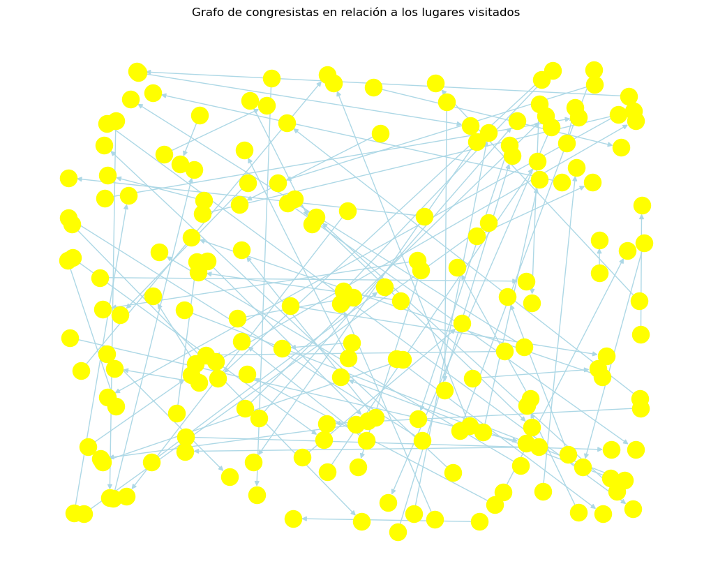

```python
import matplotlib.pyplot as plt

# Suponiendo que ya tienes el grafo G creado
# Ajusta el tamaño de la figura
plt.figure(figsize=(10, 8))

# Dibuja el grafo
nx.draw_random(G,
                node_color='yellow',
                edge_color='lightblue',
                #with_labels=True,
                font_size=5)  # Ajustar el tamaño de la fuente

# Mostrar la gráfica
plt.title("Grafo de congresistas en relación a los lugares visitados")
plt.show()
```

```python
# Importación de bibliotecas
from pyvis.network import Network

# Creación de un grafo interactivo
Gvis = Network('500px', '500px', notebook=True, cdn_resources='remote')

# Copia de tu grafo original de NetworkX
Gvis.from_nx(G.copy())

# Mostrar el grafo en un archivo HTML
Gvis.show('Gvis.html')
```

```
Gvis.html
```

[interactive chart not shown]